# Secondary RAT Data Usage Report

For EN-DC scenario, from eNB trace we can see that the gNB will send **SecondaryRATDataUsageReport** to eNB via X2AP. Below are some details regarding to secondary RAT Data Usage Report.

## TS 37.340

The secondary RAT data volume reporting function is used to report the data volume of secondary RAT to CN. In ENDC, if configured, the MN reports the uplink and downlink data volumes of used NR resources to the EPC on a **per EPS bearer** basis as specified in TS 36.300 [2]. Periodic reporting is performed by periodically sending the Secondary RAT Data Volume Report messages to the MME.

The data volume is counted by the node hosting PDCP. Downlink data volume is counted in **bytes** of PDCP SDUs successfully delivered to the UE over NR (for RLC AM) or transmitted to the UE over NR (for RLC UM). Uplink data volume is counted in **bytes** of PDCP SDUs received by the node hosting PDCP over NR. Forwarded packets shall not be counted when PDCP entity is relocated. When PDCP duplication is activated, packets shall be counted only once.

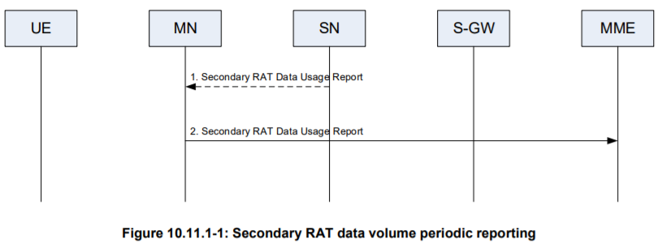

1. If the periodic reporting is configured, then the SN periodically sends the Secondary RAT Data Usage Report message to the MN and includes the data volumes of used NR radio resources for the related SN-terminated ERABs.
2. The MN sends the Secondary RAT Data Usage Report message to MME to provide information on the used NR resource.

## TS38.463

### 9.3.1.44 Data Usage Report List

This IE provides information on the data usage for the UE, e.g., secondary NR RAT in EN-DC.

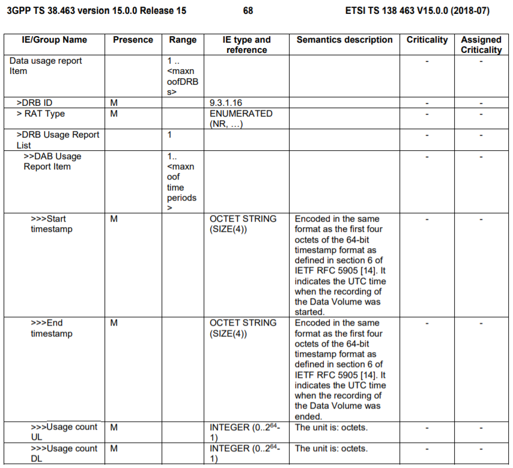

**Note: 1 octet = 8 bits**

## Example

id 265,  
criticality reject,  
value SecondaryRATUsageReportList : {  
{  
id 266,  
criticality reject,  
value SecondaryRATUsageReport-Item : {  
e-RAB-ID 5,  
secondaryRATType nr,  
e-RABUsageReportList {  
{  
id 263,  
criticality ignore,  
value E-RABUsageReport-Item : {  
**startTimeStamp ’E2 9C 51 93’H, [2020-06-23 18:01:55]**  
**endTimeStamp ’E2 9C 51 9E’H, [2020-06-23 18:02:06]**  
**usageCountUL 0,**  
**usageCountDL 2951**